# 5. At-stop schedules and TID schedules

# Process

This is how one uses the at-stop schedule system. File paths are relative to the signup folder unless otherwise mentioned.

1. Schedule files (the ones in s/final) are created, as described in the newsignup document.
2. The actium.pl sked2points program is run once, creating an intermediate form (in /p) that contains schedule information for each stop in the district.
3. The actium.pl makepoints program is run, creating InDesign tagged text files in /idpoints2016 that contain the text files to be loaded into InDesign. It also creates the files in /pointlist that are used to tell makepoints4.app what to do. If there are any errors found by the actium.pl makepoints program, they need to be fixed before the sign can be made up.
4. The maps must be updated if there are changes to the system map or line maps. The maps are in “PubInfSys – Documents/Actium/signart2016/maps”
5. The makepoints4.app script is used to make the sign artwork itself, placing the tagged text files and the maps into an InDesign file and then saving that file in /signart.
6. The user must go through each sign and see if there is any overset text or other errors with the text that was placed. Normally there isn’t, but there can be. If there is, the sign must be manually edited to make everything fit.
7. For pole schedules and shelter inserts, the “Save InDesign As PDF ask - save desktop.app” program is used to save the files as PDFs, which are then sent to the print shop in a work order.
8. For the electronic images used on the Salesforce Transit Center kiosks, these are manually exported as PNGs from the InDesign file. The resulting PNG files should be 1080 pixels tall and 1920 pixels wide. These should be sent to Pearl Media and the TJPA.
9. For TIDs and Tempo signs, the resulting InDesign files are moved into the folder TIDs/Org/AC Transit/generated. For TIDs, it’s possible that the size of the layout changed, so it may be necessary to go into the TID file for that hub (“TIDs-LKMT.indd” for Lake Merritt, etc.) and make sure the page fits properly.

## Typical service change process

Normally, one would first create the schedule files as in the newsignup document, and then run actium.pl sked2points once. Then, one would run “actium.pl makepoints -signup w22” and see if there are errors (see “Error handling” below). Once the errors have all been cleared, one would identify whatever lines have changed schedules, and then mark any signs with those changed schedules with the status “Needs update” in FileMaker. Finally, one would run the program with “actium.pl makepoints -signup w22 -update” , which creates “pl.U.txt”, and then run makepoints4.app on it. Finally, one would go through the finished signs, make sure there are no errors in the typesetting, export them, and print them (or send the ones that are not printed to their destinations).

# Program details

## actium.pl sked2points

The sked2points program takes information from the schedules in s/final and figures out the specific schedule for each individual stop. It saves them in the points files in /p. (The ones in /p/final/kpoints are the ones that are actually used.)

Invoking the program is pretty simple: “actium.pl sked2points -signup w22” from a terminal window, where “w22” is the signup in question. It should run without any need for further input.

The program is also responsible for combining schedules in a column (for example, combining 72 with 72M in a single column where appropriate).[^1]

## actium.pl makepoints

This program takes data from the FileMaker database, combines it with the point files output by actium.pl sked2points, and makes two things: the InDesign tagged text files in /idpoints2016 and the pointlist files in /pointlist.

This is one of the more complicated programs. It takes a series of switches when invoked from the command line, and many of them are critical to the operation of the program.

The format of the command line is

actium.pl makepoints <switches> <optional list of IDs>

so, for example,

actium.pl makepoints -signup w22 -update

or

actium.pl makepoints -signup w22 50250 51382 55555

#### IDs

The IDs can either be stop IDs or, for those signs that are not at stops, sign IDs preceded by N: “actium.pl makepoints -signup w22 N1933” would prepare the TID file for Castro Valley BART.

### Command-line switches

The important switches[^2] (except the ones included in the .actium.ini file,and thus not usually put on the command line) are:

#### -agency

This specifies which agency’s schedules are being produced. The valid values come from the Agencies table in the FileMaker database: the current ones are “ACTransit”, “BroadwayShuttle” (although these are not currently active), and “DumbartonExpress”. The idea is that there are separate signs for each of these agencies which are printed separately. Normally, we have a separate signup for Dumbarton Express, but because there’s only one FileMaker database, all the signs are combined.

#### -no-clusterize

This will suppress the division of signs into clusters for printing. The idea is that when printing hundreds of signs, it’s a bad idea to send them all to the pole crew or Clear Channel in one big pile, and instead divide them geographically. This is useful most of the time, but when producing a smaller number of signs not during a service change, may not be as helpful.

#### -delivery

Only processes signs with a particular delivery (“Polecrew” , “Clear Channel”, “Pacific Commons,” etc. Note that anything with a space in it will need to be quoted (‘actium.pl makepoints -s w22 -delivery “Clear Channel” ‘). These values are those from the Delivery field of the Signs table.

#### -name

This allows someone to specify a name for the files in /pointlist. Without this, the files in pointlist are given a name derived from the other options, e.g., “pl.PoleCrew.txt” for a run where “-delivery Polecrew” is given. I’m afraid which options are added to the name isn’t entirely comprehensive, so for anything complicated it’s usually best to specify some name.

#### -newsigns

Only creates signs where the “Status” field in the Signs table is “Needs new sign”.

#### -output-heights

Creates a file called “ht.<something>.txt” which provides information on the number of times (the heights) for each schedule found for that sign. See “Error handling” below.

#### -signup

This is the signup directory.

#### -tag

Only signs where the “Tag” field in the Signs table matches the entry. The tags can be anything. “actium.pl makepoints -s w22 -tag blah” will produce files for everything with “blah” in the Tag field.

#### -type

Only signs that match the value in the SignType field of the Signs database. “-type R22” will only show R22 signs.

This accepts regular expressions, which in practice I only have used for TIDs: “-type ‘TID.*’”. Doing this without -name argument will leave the “.*” in the filename, which is irritating, so I generally do “-type ‘TID.*’ -name TID”

#### -update

Only signs that have “Needs update” in the status field will be prepared. I use this frequently.

### Outputs

There are two sets of outputs.

#### Files in idpoints2016

This is what the system uses to make the finished signs, and most of the time, somebody making signs doesn’t need to be aware of them.

The schedules, effective date, and other information that is included in the sign text are placed into InDesign tagged text files, one for each sign. InDesign tagged text is a format that allows InDesign character and paragraph attibutes to be specified in a text file, and then applied to the text when placed in InDesign.

#### Files in /pointlist

There are a series of files in /pointlist. There are three segments to each of the file names – the type (pl, check, err, inst), the name of that particular invocation of the actium.pl makepoints program, and the extension. “pl.AlaCity.txt” would be the pointlist file, for AlaCity (this is a group to whom they are delivered),

The ones beginning “pl.” are the point lists themselves. They contain instructions to the makepoints4.app Applescript, which makes the signs.

The ones beginning “err” will list errors the computer found as it was running the program.

The ones beginning “check” are checklists, showing what pages need to be printed. Originally the idea was to use these to check off the signs as they were printed on our printers in the GO. Now I typically send them in the email to the installers informing them of what signs are made. Note that there are usually several Excel sheets in each one, corresponding to the cluster of signs that is to be packaged.

The ones beginning “inst” are folders, inside of which are Excel spreadsheets designed to be uploaded into WorkLog so that work orders can be made for them to be installed. There’s one spreadsheet for each cluster, which corresponds to a work order.

## makepoints4.app

This is an Applescript program. Opening it, it will ask the user to select a file, which should be one of the “pl.txt” files in the /pointlist folder of the signup folder. It will then use that file to open up the appropriate InDesign template (in PubInfSys – Documents/At Stop Schedule/Templates ), load the text for each sign, load the map for each sign if there is one in the template, and then save that InDesign file in /signart in the signup folder. Most are saved in larger clusters, but TIDs are saved one to a page, in the “TID file” specified in the FileMaker database.

It looks for the maps in PubInfSys – Documents/Actium/signart2016/maps/export. If it doesn’t find one for a page, it will display that in the dialog box at the end of when the program runs, and also save it in a file beginning “MapsNotFound-pl”, along with the name of the run, in the /pointlist directory.

## Save InDesign As PDF ask - save desktop.app

This program saves the InDesign file as PDFs, which is what the print shop uses to actually print the documents. There are two ways to run it. If you use the Finder to drop a series of InDesign files on the .app icon, it will save them all as PDFs. If you just double-click on the program, it will save the frontmost InDesign document.

It saves them in a folder “SaveAsPDF” on the user’s desktop. One thing I’ve been wanting to do to change this so it saves it in the same folder as the InDesign file instead. Oh well.

Before it saves the file, it will ask for a bleed amount. Pole schedules and shelter inserts do not need a bleed added (they are in cases which cover up their edges).

# Maps

The maps for the point schedules are found in PubInfSys – Documents/Actium/signart2016/maps. There are a series of InDesign documents, associated with the sign type. (R22 is divided into several documents because there are so many of them.) Each page of the document represents the map for one bus stop. The page number of each page is the stop ID that the map relates to. The page numbers are set using “Numbering and Section Options”.

Most maps use a segment of the system map, along with a “You are Here” symbol. A few use a segment of the system map plus an inset, and larger ones typically use the legend as well.

Although it’s basically just usual InDesign/Illustrator work (that is, there are no programming or scripts involved), there are a few complexities about placing the system map on each page. Normally one would get the updated system map file from the cartographers and replace the existing “systerm maps.ai” file with it. (The name “systerm” was an unintentional typo, but it’s easier to just keep using the bad name than tediously relink every example of it.) If the cartographers have made any changes to layers, it can be more efficient to just undo that in this copy (merging any new layers, or creating any missing ones) than to wait for it to complain about the changed layers for every file. Finally, it’s important to use “Import Options” in the Place dialog to place the correct artboard – it’s the last one, #16 “Signage”, that’s correct for segments of the regular system map. (It has more margin than artboard #1 “Overview,” which is needed for signs where the margin would otherwise cut off map objects. This is especially problematic in the Fremont area, where the Ohlone College label is right next to the edge of Artboard #1.)

A few maps use line maps from the line map repository, generally from “PubInfSys – Documents/Maps/Repository/_linesnames”.

There are two scripts that are used to export the artwork. Unlike the ones that end in “.app”, these will open in the Script Editor program and will need to be run from there. (Press the rightward-pointing triangle).

The “export_pointmaps.scpt” program will export all the pages of all the currently open documents as updated maps into PubInfSys – Documents/Actium/signart2016/maps/export. It’s important to make sure that any InDesign documents that are *not* map files are closed before running it. It takes a long time.

The “export_this_pointmap.scpt” exports just the current page as an updated map.

# Sign types and templates

Each sign type has a template file, located in PubInfSys – Documents/At Stop Schedule/Templates. In general, there are three kinds: standalone printed schedules (pole schedules or shelter inserts), schedules embedded in TIDs or Tempo signs, and the ones used for the Salesforce Transit Center electronic kiosks.

For printed signs, a sign type represents a size of a sign, and there are typically several different potential parent pages that can be used for each sign. The “actium.pl makepoints” program runs through each parent page in order and uses the first one, alphabetically, that’s big enough to fit all the text. For printed signs, S1 through S6 are various sizes of shelter inserts; Oak11 is the size used for the small “totem squares” on Clear Channel shelters, and R11, R17, and R22 are various sizes of pole schedules.

For TIDs, there are typically multiple widths, designed to take up one column in a TID, two columns in a TID, etc. The number represents the height: 16 inches or 20 inches. “TID16” uses large size type, while “TID16s” and “TID20s” use small size type.

The electronic signs for the STC kiosks are 1080L and 1080Ls, which differ only in the size of the type (“1080Ls” uses small size type).

Each sign type is represented in FileMaker in the SignType table. Each parent page is represented in FileMaker in the SignTemplate table (in retrospect, not a good name).

## Components

There are three basic components to each at-stop schedule: the background information (header art, fares, holidays, etc.), the sign text which includes the schedule, and the map.

### Background information

The background information is found on the “parent pages” (formerly known as master pages, and in some places “Master” is the name that’s used in the scripts) of the InDesign document. TIDs and Tempo signs do not have background information. For the most part, this is pretty straightforward stuff, other than there are parent pages that depend on other parent pages. Generally, the more text is on a page, the less background information is there.

### Map

Each sign may have a single rectangle that accommodates the map. (Totem squares and TIDs do not have map portions.) The rectangle has to have the Script Label “MapFrame” or makepoints4.app won’t recognize the rectangle as the right one to have the map. Some R22 parent pages are designed to accommodate so much text that the map won’t fit.

### Sign text, including schedule

Each parent page has a threaded chain of text frames. The first in the chain has to have the script label “FirstHead”, and the chain has to be grouped in a single group, which itself must have the script label “TextGroup”, or makepoints4.app won’t work properly.

The chain of text frames starts with one or more regions, consisting of pairs of schedule frames. Each pair has a frame set at an angle, which contains the line number and destination, and a long narrow frame, which contains the times. There can be multiple regions, with different lengths of frames.

After all the sets of frame pairs, there are some additional frames: the Stop ID frame (which shows the large stop ID at the upper right of the schedule), the “smoking text” frame (which has the legal code reference for the “no smoking” piece; this is marked “nonprinting” in TIDs and some other types of signs), the stop description frame (used to print the whole name of the stop), and finally one or more notes frames, generally at the right of the schedule, used to put the effective date, any footnote definitions, and the explanation of the “frequent service” icons.

There is one additional text frame, not linked to the others, with the script label “NonPrintingSignID”, that is filled by makepoints4.app to include the sign ID. Normally it’s set to be a nonprinting item (in the InDesign “Attributes” panel).

Each sign template file is part of an InDesign “book”, which is just used to synchronize the character and paragraph styles. There are two books: BigType (based on 13.2 point text) and SmallType (based on 10 point text). Two SignTypes are only distinguished by which size type they use: 1080Ls is the SmallType version of 1080L; TID16s is a SmallType version of TID16. (TID20s was the SmallType version of TID20 but TID20 is no longer in use.)

One special feature is the “Frequent Service” icon. This is stored in a custom font I made called ActiumDingbats. All the files for this are located in the TIDs folder (in the Creative Cloud file sharing) under TIDs/icons/high frequency icons . The free program “FontForge” was used to create the font.

# FileMaker tables used

Unfortunately, there are a lot of vestigial fields in the FileMaker tables that were once used and are used no longer, or alternatively, things that were planned and tables and fields created but where the project never got implemented. I realize that makes it confusing.

## SignType

Each entry in the SignType table corresponds to a template file in the in PubInfSys – Documents/At Stop Schedule/Templates folder.

The SignType field is the name of the InDesign file and is used as a foreign key in other tables. The SignTypeEnglish and SignClassification fields have been used in reports, but don’t have any actual function. Everything else is vestigial.

## SignTemplate

Each entry in this table corresponds to a parent page in a file in the PubInfSys – Documents/At Stop Schedule/Templates folder.

The SignType field says what file this is in; the MasterPage field indicates what the parent page is in the document (it’s coded to add “-Master” after this name). These are used in alphabetical preference order (e.g., first “A”, then “AM”, then “B”, etc.) The names are arbitrary, although TIDs it’s supposed to indicate the number of columns, starting with C = 1, D = 2, etc.)

The Agency field shows what agency’s background artwork is used in the document; if it’s blank, it can be used for any agency because it has no background artwork (such as TID templates).

The Regions field consists of a description of the regions of schedule text frames. The idea is that some schedules require more lines than others, so the program tries to fit the schedules on the parent page where it fits. To do that, the parent page might have a single group of schedule frames, but might also have several, each of different sizes. The Regions field has a text description of one or more regions, separated by spaces. Each region consists of the number of columns, a colon, and then the number of times that each column can accommodate. So, for example, an entry like “3:36” shows that there’s one region, with three columns, each of which can accept 36 times. An entry like “11:63 5:23 5:23” shows that there are three regions: the first has 11 columns each of which can accommodate 63 times, while the next region has 5 columns which can accommodate 23 times, and the final region also has 5 columns that accept 23 times.

## Lines

The TimetableDate field is used to set the effective date printed on each sign. The latest effective date of *any* active line is used to set the sign’s effective date, even if that date is newer than any of the lines shown on the particular schedule. (I tried using just the shown lines to show the effective date and it was confusing, especially when there were two signs on the same stop and they had different dates.)

The Color field, referencing the separate color table, is used here for the colors on the signs. This unfortunately cannot handle lines that have branches with different colors, or combined frequencies as on 72/72M.

## Agencies

The only field used here is the “EffectiveDate,” which can be set to a later date than any TimetableDate from the Lines field should that be appropriate.

## Signs

The “signs” table is the most important one. Each record provides information about a specific at-stop schedule.

There are a number of important fields.

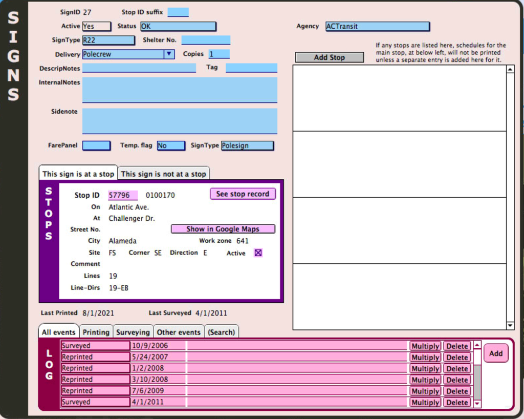

SignID – a numeric ID for each sign. Signs not located at stops use this number, preceded by N, as the number given on the signs.

Stop ID suffix – If there is more than one sign at a stop, it adds a suffix to uniquely identify the sign – “55555A” and “55555B”. Normally it just picks the next letter that hasn’t been used, but if this is filled, it will use the suffix specified.

Active – this is a calculation based on the value of the “Status” field. A status of “Removed” gives “No”; a status of “On hold,” “To remove,” or one of the “Suspended” statuses gives “Sort of”; others give “Yes.”

Status – This is the status of each sign. Potential values are:

Needs update

Needs new sign

OK

To remove *(we have requested removal but this has not been confirmed)*

Suspended *(has only lines suspended during COVID)*

Suspended except schools

Suspended except dropoff

Suspended exc sch & drop

Removed *(confirmed removed)*

Needs no service sign *(needs a sign saying “buses don’t stop here anymore”, generally for shelters where Clear Channel hasn’t taken the shelter down)*

Has no service sign

At printer *(not used anymore; this was used when we sent things to print shops and then had them returned to us before forwarding them to the installers)*

On hold *(was used when a shelter was pending the installation of a case, back when this actually happened)*

SignType – reference to the SignType table above.

Shelter Number – an number used by Clear Channel for their shelters

Delivery – the company, or whoever, who will install these signs. Most are installed by the AC Transit pole crew or by Clear Channel, but see below under “Installation.”

Copies – This is the number of copies of each sign that needs to be printed. Shelters and kiosks sometimes require more than one copy of each sign to be printed.

DescripNotes – notes printed along with the stop name

Tag – used to allow the -tag switch to be used in actium.pl makepoints

InternalNotes – notes to ourselves, not displayed.

SideNote – notes printed on the side of the sign

FarePanel – for Clear Channel shelters with totems, shows how large the fare panel is for that shelter

StopID – for signs at stops, indicates what stop this is at. A reference to the Stops_Neue table

Agency – which agency’s schedules should be printed on this sign. A stop shared by Dumbarton Express and AC Transit, for example, should have two signs, one sign with the “Dumbarton Express” agency listed and one with the “AC Transit” agency listed.

Under “This sign is not at a stop,” there are several fields. “Location” is a text description of the location. “City” is what city it’s in. “TID file” is the name of the InDesign file that will be saved. Note that at one point these were supposed to be saved in separate subdirectories, but I changed that, and rather than editing all the entries I just told the program to ignore anything before a leading slash. So “Castro Valley/CAST” will end up just being saved as “CAST”.

There are two boxes on the Signs entry form that provide access to other tables.

SignLog -- This allows one to keep records of which signs have been printed, surveyed, or other actions taken. I’m not going to go into this in detail because it hasn’t changed in a very long time, we don’t do the same kind of reporting that we used to, and anyway, Tony knows about it (or did).

Stops -- The entries on the right allow specifying schedules separately from the location of the sign itself. This is useful when one is preparing a sign not at a stop, or where one has multiple signs at a stop. The “omit list” allows one to specify lines that should *not* be printed. (Because lines change all the time and most of the time unknown lines should be printed, specifying lines that are omitted rather than specifying lines to be included leads to fewer errors.) One can choose to omit either: lines in any direction by specifying a line number (“7”), or lines in one direction only by specifying the direction (“7-NB”). Lines or line-direction specifications should be separated by spaces. (For those working on the system, there’s a join table called “Signs-Stops-Join”)

## Stops_Neue table

The programs use the location text specified in this table for the stop description on each sign.

## Places_Neue table

The programs use the timepoint names from this table for the timepoint names on the signs, and the destination names for the destinations on each sign.

## Cities table

The SmokingText field contains the legal code reference for the printed restriction against smoking at bus stops.

# Error handling

The system is designed to do the best it can to place the signs, but it’s far from perfect and there are things it doesn’t handle. Several stages have errors that are common. It doesn’t mean the program will not work, but it does mean it can’t handle that particular sign entry.

## actium.pl makepoints errors

There are a number of errors that happen from “actium.pl makepoints”.

Normally, at the beginning of a service change, one would first run the newsignup routine and then “actium.pl sked2points.” Then, one would run the entire set of schedules with a non-specific “actium.pl makepoints -s signup”. This will run through all the signs and create the InDesign Tagged Text files, but the actual point is for it to create the “err.txt” file in the pointlist folder. This will list all the errors that were found.

The usual process is to make changes to clear errors, and then re-run the program, and continue this process until no errors are found. (It doesn’t delete the “err.txt” file if there are no errors, so one has to look for the “VALID” on the display to make sure no errors were found.)

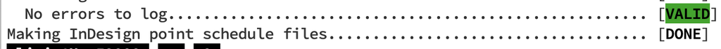

### Stop not found

The most common error is when a stop isn’t found: where a stop identified in the FileMaker database associated with a sign has no lines associated with it. This can be the main stop where a sign is located, or a stop in the list of associated stops.

Usually, at a service change, some stops will be eliminated, and these will show up as “Stop not found” in the err.txt file. In some cases, there is no replacement stop, and so the Status field in the Signs database should just be changed to “To Remove” or “Removed” (and, if necessary, a work order sent to remove the sign). In other cases, the stop ID should be changed to the stop ID of its replacement stop.

### Line found in omit list but not in schedule data

Sometimes when a line is moved, the omit list of a stop associated with a sign is no longer accurate. This will identify that. The omit list needs to be updated to reflect the new lines serving that stop.

### No sign template found

The other common error is “No sign template found” which means that the program couldn’t find a sign template that could fit that number of schedules. The program knows how to divide columns into halves or thirds, and it tries what it can to try to make it fit. But sometimes it just can’t.

The easiest thing to do is to make a second sign entry, which means adding a second pole schedule, or using both sets of totem squares in the kind of shelter that uses those. (The stop then has to be added in the list of stops on the right of the entry screen, and then the “omit list” has to be used to make sure that each schedule is only used on one of the signs.) It’s not always possible to add a second physical sign in the field, though.

What often needs to happen is that a new sign template is created that can accommodate it. Unfortunately, the way the system works makes it quite possible that there’s enough room on the sign, but that the specific lengths of column available on each parent page makes them not quite fit. Dealing with this means going into the sign template file, duplicating an existing page, and adjusting it so it happens to fit the sizes properly.

Using the -output-heights switch to actium.pl makepoints will have it create a list of heights for each schedule, in the file ht.<something>.txt

N2632 58:99_12345_1 58:99_12345_0 41:99_67_1 41:99_67_0 35:210_12345_0 34:210_12345_1 27:210_67_0 25:210_67_1 13:801_1234567_1 13:801_1234567_0 13:251_12345_1 13:251_12345_0 13:251_67_1 13:251_67_0 5:U_12345_3

This says for sign N2632 there are 58 times needed for the schedule “99_12345_1” (99, weekdays, southbound), 58 times for the schedule “99_12345_0” (99, weekdays, northbound), and so forth, through 5 columns needed for “U_12345_3” (U, weekdays, westbound).

A template needs to be built that handles all these columns. Generally in situations like this, the key is to create different regions that will handle these specific numbers (possibly divided into even fractions of halves or thirds). But it’s hard to say before the fact how to do this.

Once the template is made, an entry needs to be made in the SignTemplates table for it, and actium.pl makepoints run again to make sure it will fit.

### No columns for this sign

This generally means a stop only has 600-series lines or only drop-off-only service. Signs at stops like this should be removed and their entries marked as inactive in the FileMaker database.

## makepoints4.app errors

If makepoints4.app doesn’t find a map for a sign, it will indicate this by including it in the dialog box at the end of the run, and also by saving the list of maps not found in the file “MapsNotFound-pl.txt” in the pointlist folder.

The remedy is, of course, to make a map for that sign in the appropriate InDesign document (as described above under “Maps”). One can then either export the map as a PDF and re-run makepoints4.app, or – which is usually easier if one only has a few missing maps – just copy and paste the map artwork onto the final document.

## InDesign placement errors

Usually, each sign is loaded without errors, but sometimes some piece of text is longer than the text frame allocated for it can handle. Usually this leads to an “overset text” preflight error in InDesign, but not always. One has to look at each sign and make sure no errors like this exist, and if they do, manually correct them.

The most common thing is that the header of a column is overlong and needs to be shrunk. The recently added note about frequent service also sometimes is longer than the space available for it.

Editing the templates to increase the size available to column headers and to the side notes would minimize these problems. (It would be ideal to at least change all the column headers so that the top line is horizontal, increasing the size of the header without actually taking up more space on the page. I did this for parent page A-Master in the R22 template, to provide an example of what I mean.)

The other error is that InDesign has a bug where overriding a parent page item in a script causes the item to move to an incorrect location. The page items need to be manually moved to the correct location. (This is caused by pages having been resized during the creation of the template file. Recreating the template file from scratch, using the original page size, should avoid this if one wants to eliminate the problem in the future.)

# Printing and Installation

Most signs are installed by the AC Transit pole crew. Others are installed by shelter owners; still others are incorporated in TIDs and sent to whoever is installing the TID.

Printed signs are sent as PDFs to the print shop. Except for pole schedules installed by the pole crew, the address to which they should be sent should be included.

# Future

The at-stop schedule system originated a long time ago, and it’s fair to say that it’s not as important as it used to be, when there was no real-time information and people used at-stop schedules to find out when the next bus should come. Many fewer people do that nowadays.

But real-time information only works for the next hour. Anybody wanting to know more generally when the buses run, or plan a trip for later in the day, needs a schedule. Moreover, it is good marketing to tell *potential* riders when the bus runs.

Having said that, the existing schedules are a mild evolution of a design that’s over twenty years old, and they have a lot of problems.

- The 65° angle of the column headers is difficult to read, and the columnar layout can be wasteful of space. The way the system works, filling one of a series of premade templates with text, isn’t as flexible as a script that could reshape the areas used for lines.
- The design was originally intended for pole schedules, and two directions of the same line, common on TIDs, aren’t differentiated very well. The distinction between weekday, Saturday, and Sunday isn’t as clear as it ought to be.
- Other than the map, there’s no information on any of the places the bus serves. It would be useful to have the long line descriptions, and points of interest served by the routes.
- The system map is useful for showing where the bus line goes, but it could be argued that it’s the wrong scale for pole schedules. A local street and transit map , more on the scale of the 2002-2009 map, would be more useful for pole schedules. An ideal system would use map data (from OpenStreetMap or something) to create that, centered on the location of the stop.

An updated design, with clearer headings and better display of weekdays/Saturdays/Sundays, would be ideal. (I wrote some ideas on this in boxpoints.md in the Github repository )

Nonetheless, I don’t know that any of this can happen now. I’m hoping this document will make it possible to continue maintaining these things as they are until the systems are replaced.

[^1]: The program determines whether columns should be combined by looking at all following stops, and if enough of them are identical, combining the columns. Actually this turned out to be slightly incorrect – instead of looking only at following stops, it should treat the stops as identical if *either* the timepoint or the stop is identical – we have examples where all stops are identical except for the final stop at a BART station transit center. Also, it doesn’t combine schedules if the set of days are different, so that e.g. 51A and 851 can’t always be combined, even though it’s basically the same line heading southbound, because 851 has all seven days on the same schedule while 51A has separate Saturday and Sunday schedules.
[^2]: Note that switch names can be abbreviated to the shortest unique entry. So, for example, “-signup” is the only switch that begins with “s” so it can be just specified as “-s”, while “-t” doesn’t suffice because there are both “‑tag” and “-type” switches. Only the important ones are listed here; you can do “actium.pl makepoints -help” for a complete list. The “-help” switch works with all actium.pl programs to at least print a list of options.